# Dashboard Types, Design Workflow and Strategies

Cheng Peng

West Chester University

# 1 Introduction

Before opening a tool, we must accept a fundamental truth: a single dashboard cannot serve all masters. A dashboard that tries to be a real-time alert system, an executive summary, and a root-cause investigation tool will fail at all three.

This note is structured around three distinct archetypes. Each has a different heartbeat, a different audience, and a fundamentally different question it answers.

| Archetype | Primary Question | Audience | Time Horizon | The Metaphor |
| --- | --- | --- | --- | --- |
| Monitoring | “What is breaking right now?” | Operators, NOC, SRE | Now (seconds/minutes) | The Nervous System |
| Managerial/Executive | “Are we winning long-term?” | VPs, C-Suite, Directors | Future (weeks/quarters) | The Strategic Map |
| Diagnostic/Exploratory | “Why did this happen?” | Analysts, Sr. Managers | Past (hours/days) | The Detective’s Board |

**The Golden Rule**: Always start by declaring which of the three lenses you are building for. Write it on a sticky note: “This is an Executive dashboard.” This single act will save you from 80% of bad design decisions.

# 2 The Monitoring Dashboard

**Purpose**: Trigger an immediate, correct physical action when a system deviates from a defined healthy state.

## 2.1 Map the Operational Lifecycle & Tripwires

In a monitoring dashboard, the primary objective is not to visualize raw data itself, but to visualize how the data relates to predefined thresholds, targets, or acceptable operating ranges.

## 2.2 A Suggested Single-Screen Triage Layout

Design strictly for the 2:00 AM, half-asleep brain. Use a strict grid.

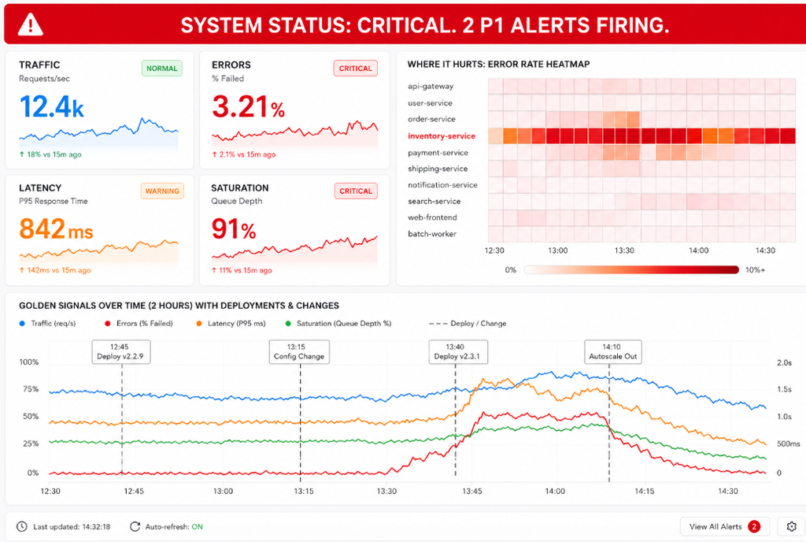

```r
include_graphics("img/monitoringdash.png")
```

## 2.3 Design the Explicit Call to Action

A monitoring dashboard fails if it merely alerts without directing the response.

- **Action**: Make the Red KPI tile itself a hyperlink. The link doesn’t go to more data; it goes directly to the pre-populated incident runbook for that specific failure mode.
- **Final Audit**: Apply the “Squint Test.” Squint at your screen. If you can’t clearly see the red zones, your visualization has failed. Remove all chart borders, heavy gridlines, and non-critical color until the alert state is the only thing with visual weight.

# 3 The Executive/Managerial Dashboard

Purpose: Interactive executive dashboards integrate many disparate data sources, making it easy to monitor performance across the business, or drill down into granular data sets to inform almost any action they need to take. Different executive dashboards use different performance metrics. Executives use dashboards to validate a high-level strategy and guide resource allocation decisions for future.

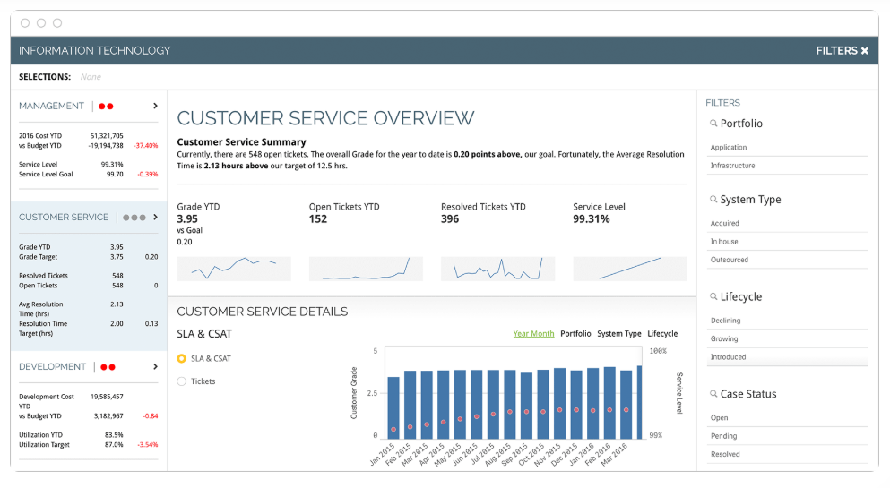

```r
include_graphics("img/CIODashboard.png")
```

## 3.1 Build the “3-Horizon” Metric Framework

Executives balance the present and the future.

- **Horizon 1**: Run the Business (Defend). This quarter’s revenue, retention, and margins. “Are we hitting our numbers?”
- **Horizon 2**: Grow the Business (Expand). New product traction, sales pipeline velocity, marketing qualified leads. “Where is our momentum?”
- **Horizon 3**: Transform the Business (Disrupt). R&D milestones, strategic partnership outcomes. “Are we planting seeds for year 3?”
- **Action**: Force yourself to have at least one, but no more than two, metrics for each horizon. If it doesn’t fit, it’s out.

## 3.2 The “Analyst Opinion” as a Headline

Executives don’t want raw data; they want your synthesized judgment. The most valuable visual is text.

- **Action**: At the very top-left of the dashboard, place a rich-text card. This is manually or AI-curated weekly.
- **Content Formula**: Performance Statement + Key Driver + Leading Risk + Recommended Action.
  - **Example**: “We are on track for Q3 targets (+4% MoM ARR), driven by strong Enterprise expansion. However, SMB logo churn ticked up to 3%. Risk: The SMB base is unstable. Recommendation: Focus sales engineering resources on at-risk SMB accounts listed in Table 2 this week.”
- **Design**: This is a large font, narrative block. It frames the entire dashboard below it as supporting evidence for these sentences.

## 3.3 Construct the “Magic Triangle” of Trade-offs

This is a dedicated, unmissable section visualizing the core tension of business: Growth vs. Efficiency vs. Health.

- **Layout**: Three large gauges or combo charts in a single row.
  - **Growth (Speed)**: YoY Revenue Growth %. Sparkline showing trend.
  - **Efficiency (Cost)**: CAC Payback Period (Months). Bullet gauge with a target.
  - **Health (Quality)**: Net Revenue Retention (NRR) or Voluntary Employee Attrition.
- **The Narrative**: This row forces a strategic dialogue. “Growth is up, but efficiency is down” is the exact story an executive needs to manage.

## 3.4 Visualize the Portfolio with “Small Multiples”

As a fundamental principle of effective analytic visualization, never use a single aggregation when a breakdown reveals the story. Don’t use a pie chart. Use small multiples.

- **Action**: Create a grid of 8-16 identical tiny sparkline charts. Each one is a product line, a region, or a team.
- **Design**: All share a common X-axis (Last 8 Quarters) and Y-axis (Revenue). Sort them by trend, not alphabetically. The one with a cliff-dive pattern will scream for attention, instantly showing where the strategic problem lies.

## 3.5 The TSA Status Board for Initiatives

Map the health of strategic projects that consume budget.

Action: Build a table. Rows are the CEO’s top 5 strategic bets. Columns are: Budget, Timeline, Talent, Key Milestone. Cells are color-coded (R/Y/G) based on the latest review.

The Narrative: A single row that is entirely red tells the story: “Our flagship AI project is silently derailing.” This is a resource allocation story, not an operational one.

# 4 The Diagnostic/Exploratory Dashboard

Purpose: To guide an analytical mind through a structured, layered investigation from a high-level symptom to a granular, actionable root cause.

## 4.1 Write the “Big Question” and the Drill-Path

This is the most guided of all dashboards. We must build a ladder of questions.

- **Action**: Start with the single analytical question: “Why did Q3 Sales miss target?”
- **Design the “Why Ladder” on paper**:
  - **Ladder Rung 1**: “Where did we miss?” (By Region)
  - **Ladder Rung 2**: “In the failing region, which reps/teams missed?” (By Team)
  - **Ladder Rung 3**: “For the failing team, which deals slipped?” (Specific Opportunities)
  - **Ladder Rung 4**: “What is common to those slipped deals?” (Competitor, lack of SE support, product gap?)

## 4.2 Build the Evidence Layer (Top 60% of Screen)

This section proves the headline.

- **Layout**: A single row of KPI summary tiles at the top, not for action, but for context. “Total Q3 Revenue: $11.8M vs. $12.5M Target (-5.6%).”
- **Primary Visual**: A compelling “what vs. what” chart. For the sales miss, this is a Waterfall Chart: Starts with the target, shows the negative contribution of each failing region, and ends with the actual. This visually decomposes the miss.
- **Secondary Visual**: A Time-Series Overlay. Plot actual weekly revenue against the weekly forecast and last year’s trend. The point where the blue line of actuals diverges from the green band of the forecast is the moment in time where the story began.

## 4.3 Construct the Guided Drill-Down (Bottom 40% of Screen)

This is where you prevent the user from getting lost. Your job is to pre-package the “next click.”

- **Action**: Use an interactive element (a drop-down or a clickable chart) that filters the detailed table below.
- **The Table is Not Raw Data**: The final table is not a data dump. It’s a curated “Hit List.” If a region is selected, the table shows the specific opportunities that slipped. Columns are narrative elements: Opportunity Name, Value, Sales Stage, Days in Stage vs. Average, Last Activity Date.
- **The Narrative**: The user has been guided from “We missed target” to “The West Region missed” to “These 3 specific mega-deals stalled in the negotiation stage because there’s been no activity in 30 days.” The action is immediately clear: call those 3 clients.

# 5 The Universal Final Audit For Any Dashboard

Before declaring any dashboard finished, run through this checklist to enforce the core principle of its type.

- **The Type Test**: Does it answer the one core question of its type (What is breaking? / Are we winning? / Why did it happen?) If it tries to answer two, start a new dashboard.
- **The 5-Second Test**: Show it to a colleague who has never seen it. After 5 seconds, hide it and ask, “What is the single most important takeaway?” If they can’t answer clearly, your visual hierarchy has failed.
- **The “So What?” Test**: Point to every single element, number, and line. Ask “So what?” If the answer is “Hmm, that’s interesting,” delete it. If the answer is “It means we should immediately do X, investigate Y, or reallocate Z,” it stays.
- **The Ink-to-Data Ratio**: Edward Tufte’s principle. Mentally erase all the ink that is not actual data. Gridlines, heavy borders, icons, and decorative gradients are noise. Subtract them. The remaining data will speak louder.
- **The Source of Truth**: In the footer, in a 9pt font, state the exact data source, query name, and freshness (“Data as of: Last 1 hour from Snowflake sales.opps table”). Trust is built on transparency, never a black box.

We have now discussed the complete workflow of dashboard design. The choice of tool—whether Tableau, Power BI, or a custom-coded solution—is ultimately secondary. What truly matters is the discipline of beginning with a clearly defined purpose and a coherent narrative. No amount of sophisticated animation, real-time data connectivity, or interactive filtering can rescue a dashboard that lacks a focused question or a logical story. **Great dashboards are not built by tools; they are built by thoughtful designers who understand the questions, the context, and the decisions that matter**.